# Managing for ecological surprises in metapopulations

Supplemental materials: Model details & results

Elissa Sweeney-Bergen$^\textup{a,c}$, Emma E. Hodgson$^\textup{a,d}$, Kara J. Pitman$^\textup{a}$, Karl Seitz$^\textup{a}$, Lauren Law$^\textup{a,d}$, Luke Warkentin$^\textup{a,d}$, Samantha M. Wilson$^\textup{a}$, William I. Atlas$^\textup{a,e}$, Douglas C. Braun$^\textup{d}$, Matthew R. Sloat$^\textup{e}$, M. Tim Tinker$^\textup{f}$, and Jonathan W. Moore$^\textup{a,b}$ $^\textup{a}$Earth to Ocean Research Group, Simon Fraser University $^\textup{b}$Resource and Environmental Management, Simon Fraser University $^\textup{c}$Fisheries Department, Lake Babine Nation $^\textup{d}$Fisheries and Oceans Canada $^\textup{e}$Wild Salmon Center $^\textup{f}$Ecology and Evolutionary Biology, University of California Santa Cruz Kyle L. Wilson$^\textup{a}$[^1], Alex Sawyer$^\textup{a}$, Anna Potapova$^\textup{a}$, Colin J. Bailey$^\textup{a}$,Daniella LoScerbo$^\textup{b}$,

25 March 2021

## Metapopulation model

### Local & metapopulation dynamics

Our metapopulation is defined by a set of local populations $N_p$ for a species with a one year generation time with time-dynamics that follows birth (i.e., recruitment *R*), immigration, death, and emigration (BIDE) processes typical in metapopulation theory (Hanski 1998):

$$\begin{align}
N_{i{t+1}}= R_{it}\epsilon_{it}+I_{it}-D_{it}-E_{it}
\end{align}$$

where $N_{it+1}$ is the number of adults in patch *i* at time *t+1*, $R_{it}$ is number of recruits at time *t*, $I_{it}$ is number of recruits immigrating into patch *i* from any other patch, $D_{it}$ is number of recruits that die due to disturbance regime, $E_{it}$ is the number of recruits emigrating from patch *i* into any other patch, and $\epsilon_{it}$ is stochasticity in recruitment.

Resoure monitoring often occurs at the scale of the metapopulation (Anderson et al. 2015), hence we define metapopulation adults as:

$$\begin{align}
{MN}_t = \sum_{i=1}^{N_p} N_{it}
\end{align}$$

with metapopulation recruits:

$$\begin{align}
MR_t = \sum_{i=1}^{N_p} R_{it}
\end{align}$$

Local patch recruitment at time *t* depended on adult densities at *t-1* and followed a reparameterized Beverton-Holt function:

$$\begin{align}
R_{it}=\cfrac{\alpha_iN_{it-1}}{1+\cfrac{\alpha_i-1}{\beta_i}N_{it-1}}
\end{align}$$

where $\alpha_i$ is the recruitment compensation ratio and $\beta_i$ is local patch carrying capacity.

Management often monitors metapopulation resources as the aggregate of all local populations. For example, take a two patch metapopulation model that varies $\alpha_i$ and $\beta_i$ parameters where:

```r
alpha <- c(2, 4)
beta <- c(100, 200)
```

Here, recruitment compensation from local patches $\alpha_i$ gets averaged across the metapopulation leading to an average compensation ratio $\bar{\alpha}$ of 3. Likewise, the total carrying capacity of the metapopulation $\bar{\beta}$ becomes the summation of local patch carrying capacities $\sum\beta_i$, which is 300. This scale of monitoring generates the following local patch and metapopulation dynamics:

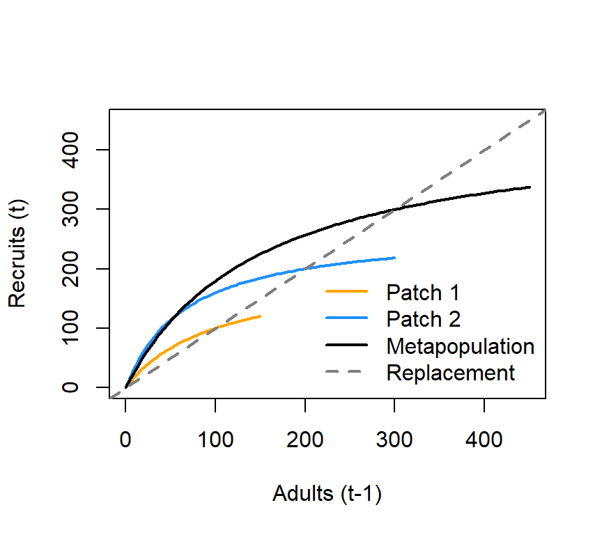

Metapopulation and local patch recruitment dynamics.

### Creating the spatial networks

The next aspect to our metapopulation model is connecting the set of patches to one another (Yeakel et al. 2014). We need to specify the number of patches, their arrangements (i.e., connections), and how far apart they are from one another. We followed some classic metapopulation and source-sink arrangements to create four networks that generalize across a few real-world topologies: a linear habitat network (e.g., coastline), a dendritic or branching network (e.g., coastal rivers), a star network (e.g., mountain & valley, or lake with inlet tributaries), and a complex network (e.g., grasslands).

To make networks comparable, each spatial network type needs the same leading parameters (e.g., number of patches $N_p$ and mean distance between neighboring patches $\bar{d}$). In this case, we set $N_p$ to `16` and $\bar{d}$ to `1` unit (distance units are arbitrary). We used the `igraph` package (Csardi & Nepusz 2006) and some custom code to arrange our spatial networks as the following:

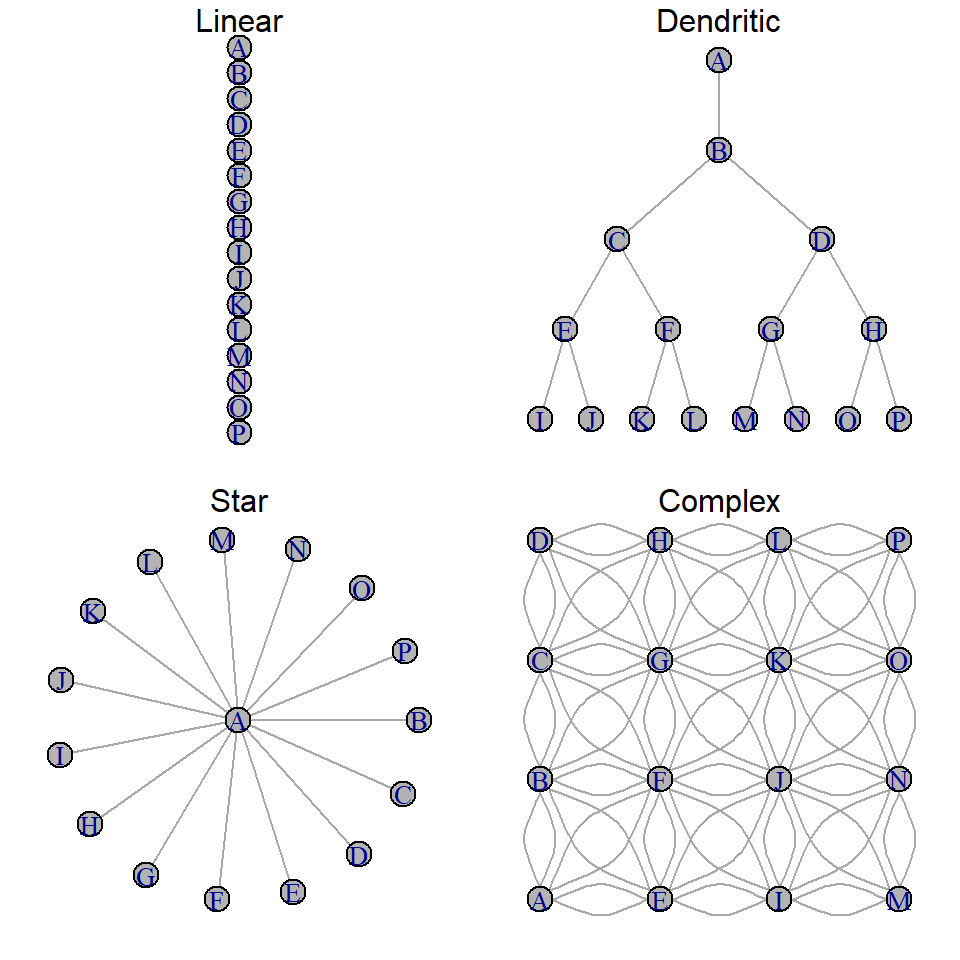

Four spatial network topologies.

Note that distances between neighbor patches in the above networks are equal.

An example dispersal matrix for the complex network:

```
##   A B E F C G D H I J K L M N O P
## A 0 1 1 1 2 2 3 3 2 2 2 3 3 3 3 3
## B 1 0 1 1 1 1 2 2 2 2 2 2 3 3 3 3
## E 1 1 0 1 2 2 3 3 1 1 2 3 2 2 2 3
## F 1 1 1 0 1 1 2 2 1 1 1 2 2 2 2 2
## C 2 1 2 1 0 1 1 1 2 2 2 2 3 3 3 3
## G 2 1 2 1 1 0 1 1 2 1 1 1 2 2 2 2
## D 3 2 3 2 1 1 0 1 3 2 2 2 3 3 3 3
## H 3 2 3 2 1 1 1 0 3 2 1 1 3 2 2 2
## I 2 2 1 1 2 2 3 3 0 1 2 3 1 1 2 3
## J 2 2 1 1 2 1 2 2 1 0 1 2 1 1 1 2
## K 2 2 2 1 2 1 2 1 2 1 0 1 2 1 1 1
## L 3 2 3 2 2 1 2 1 3 2 1 0 3 2 1 1
## M 3 3 2 2 3 2 3 3 1 1 2 3 0 1 2 3
## N 3 3 2 2 3 2 3 2 1 1 1 2 1 0 1 2
## O 3 3 2 2 3 2 3 2 2 1 1 1 2 1 0 1
## P 3 3 3 2 3 2 3 2 3 2 1 1 3 2 1 0
```

### Dispersal

Dispersal from patch *i* into patch *j* depends on constant dispersal rate $\omega$ (defined as the proportion of total local recruits that will disperse) and an exponential distance-decay function between *i* and *j* with distance cost to dispersal $m$ following Anderson et al. (2015):

$$\begin{align}
E_{ij(t)}=\omega R_{it}p_{ij}
\end{align}$$

where $E_{ij}$ is the total dispersing animals from patch *i* into patch *j* resulting from dispersal rate $\omega$, total number of local recruits $R_{it}$, and probability of dispersal between patches $p_{ij}$:

$$\begin{align}
p_{ij}=\dfrac{e^{-md_{ij}}}{\sum\limits_{\substack{j=1 \\ j\neq i}}^{N_p} e^{-md_{ij}}}
\end{align}$$

where $d_{ij}$ is the pairwise distance between patches, $m$ is the distance cost to dispersal. The summation term in the denominator normalizes the probability of moving to any patch to between 0 and 1 with the constraint that dispersers cannot move back into their home patch (i.e., $j\neq i$. With $\bar{d}= 1$, $m=0.5$, $\omega=0.1$, $R_{it}=100$ in a linear network:

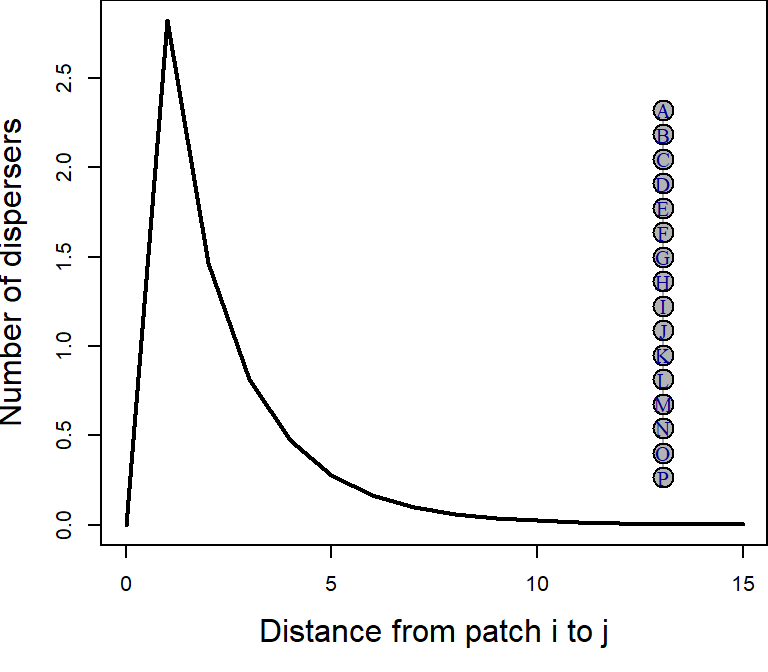

Example dispersal patterns across linear network.

### Disturbance regimes

In all scenarios, disturbance was applied after `50` years of equilibrating the metapopulaton at pristine conditions. We then applied the disturbance regime at year `50` (the regime varied from *uniform*, *localized, even*, and *localized, uneven* - see *Scenarios* below). Disturbance immediately removes a set proportion of the metapopulation adults at that time (i.e., `0.9` of $MN_{t=50}$). Once applied, the metapopulation was no longer disturbed and spatio-temporal recovery dynamics emerged naturally from these new conditions.

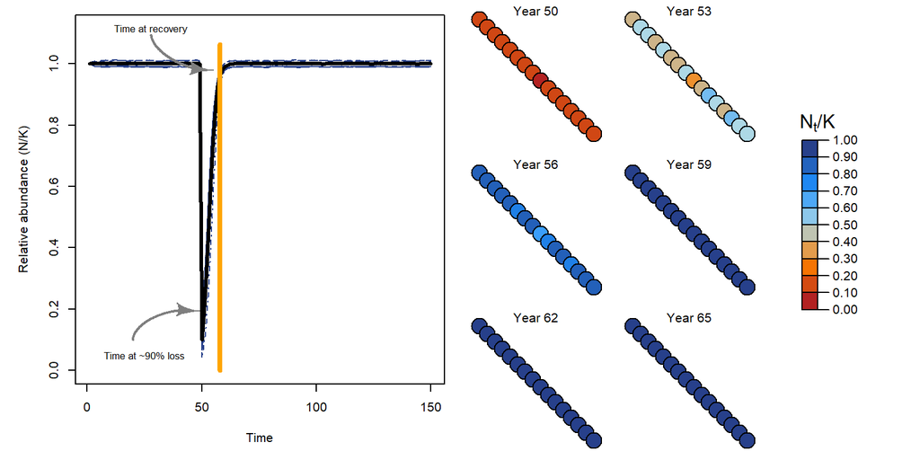

Recovery regime of metapopulation with linear topology through time (left) and space (right).

### Recruitment stochasticity

Our model allowed for stochastic recruitment that followed a lognormal distribution with average variation in recruitment of $\sigma_R$. In cases of stochastic recruitment, the expected recruitment:

$$\begin{align}
R_{it}=\cfrac{\alpha_iN_{it-1}}{1+\cfrac{\alpha_i-1}{\beta_i}N_{it-1}}
\end{align}$$

becomes:

$$\begin{align}
R_{it}=\cfrac{\alpha_iN_{it-1}}{1+\cfrac{\alpha_i-1}{\beta_i}N_{it-1}}e^{(\epsilon_{it}-\cfrac{ln(\sigma_{R}^2+1)}{2})}
\end{align}$$

where lognormal deviates for each patch *i* at time *t* are drawn from a multivariate normal distribution (*MVN*) If $\sigma_R$ is low, then metapopulation dynamics approach the deterministic case. In some scenarios, we evaluated the role of spatially and/or temporally correlated deviates across local patches to model potential common drivers affecting metapopulation dynamics (e.g., Moran effects). Expected recruitment deviates followed a first-order autoregression model such that:

$$\begin{align}
\epsilon_{it}=\rho_T\epsilon_{t-1}+MVN(\mu=0,\Sigma=\sigma_R(1-\rho_T^2)e^{(-\rho_SD_{ij})})
\end{align}$$

where $\rho_T$ is temporal correlation (bounded $0-1$) $\rho_S$ is rate of distance-decay in spatial correlation (bounded $0-\infty$ with higher values leading to independent patches). If $\rho_T$ is 0 and $\rho_S$ is high, then annual recruitment deviates are independent. We illustrate the effects of four kinds of recruitment deviates below using the same random number generator seed:

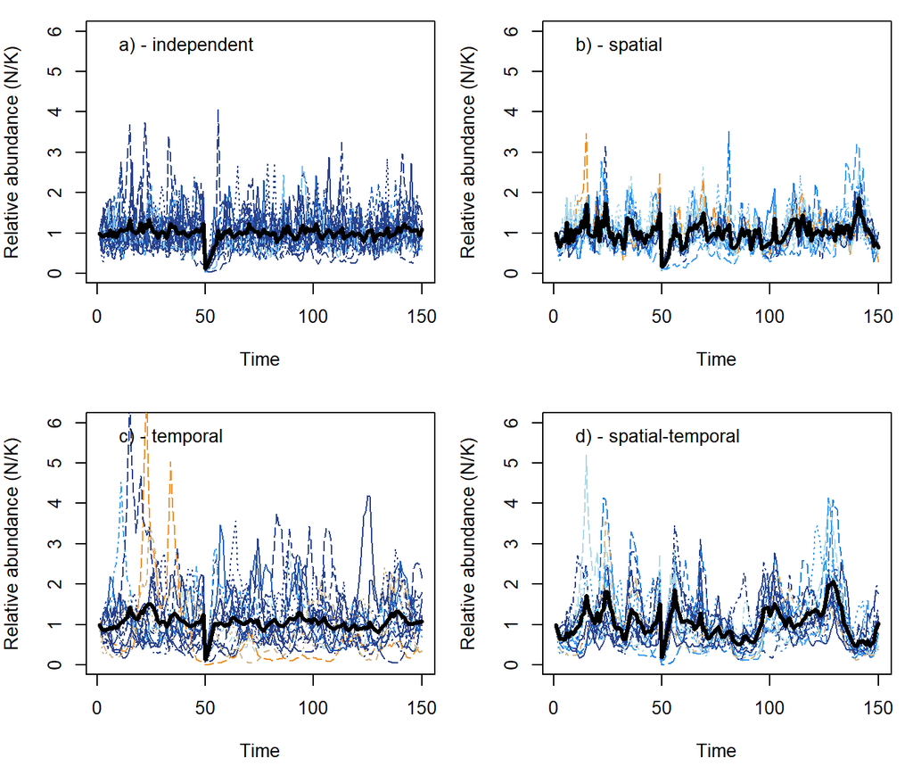

Metapopulation dynamics with independent (a), spatially correlated (b), temporally correlated (c), and spatio-temporally correlated (d) recruitment deviates. Black line indicates metapopulation, and dashed lines indicate local patches with red and blue relating to abundances after 100 years post-disturbance were less than or greater than 1.0 pre-disturbance, respectively.

## Post-disturbance outcomes

We measured the following post-disturbance outcomes to track the temporal and spatial recovery regime of the metapopulation.

1. Non-recovery (a) & recovery rate (b) after disturbance:
   1. Non-recovery rate is defined as the % of simulations where metapopulation abundance failed to recover to `1.0` of the average pre-disturbance abundance for `5` consecutive years post-disturbance. This “non-recovery rate” reflects the risk of a long-term state shift in metapopulation dynamics after disturbance in the face of stochasticity.
   2. Recovery rate represents the proportional post-disturbance recovery towards metapopulation carrying capacity gained per year (1 year = 1 generation in our models). Recovery rate was calculated as $1-T_{recovery}/T_{sim}$ where the recovery time, $T_{recovery}$, was the number of years/generations it took for the metapopulation to reach five consecutive years ≥ pre-disturbance abundance. Recovery rate captures how quickly the aggregate metapopulation recovers from disturbance but doesn’t take into account whether any given local patches recover to their pre-disturbance capacity nor did it allow for any uncertainty around recovery criteria.
2. Patch occupancy - the mean number of patches with `>0.1` local carrying capacity after disturbance in the short-term (5 years), medium-term (10 years), and long-term (25 years). This value characterizes the expected risk of spatial contractions or local patch collapses, and reflects how interactions between spatial structure, disturbance, and dispersal shape source-sink dynamics and the ability to provide (or not) rescue effects and recover local patches.
3. The ratio of expected maximum surplus production (we term *MSY*) to true maximum surplus production summed across all patches from fitted stock-recruitment model to aggregate across metapopulation such that:
   $$\begin{align}
   \Delta_{MSY}=\cfrac{\hat{MSY_M}}{\sum_{i=1}^{N_p} MSY_{i}}
   \end{align}$$
   A value of 1.0 would indicate that the disturbed metapopulation can sustain itself against the same disturbance regime as the sum of each patch independently. In other words, is the metapopulation more than ($\Delta_{MSY}$>1.0), less than ($\Delta_{MSY}$<1.0), or equal to the sum of its parts ($\Delta_{MSY}$=1.0). We detail how *MSY* is estimated further below.

### Monitoring & management at aggregate-scale

While true metapopulation dynamics are controlled by local patch dynamics and dispersal such that:

$$\begin{align}
N_{it}= R_{it}\epsilon_{it}+I_{it}-D_{it}-E_{it}
\end{align}$$

$$\begin{align}
R_{it}=\cfrac{\alpha_iN_{it-1}}{1+\cfrac{\alpha_i-1}{\beta_i}N_{it-1}}
\end{align}$$

$$\begin{align}
{MN}_t = \sum_{i=1}^{N_p} N_{it}
\end{align}$$

$$\begin{align}
{MR}_t = \sum_{i=1}^{N_p} R_{it}
\end{align}$$

Natural resoure managers often monitors and manages at the scale of the metapopulation. Hence, management at this scale inherently defines the stock-recruitment dynamics of the aggregate complex of patches (i.e., metapopulation) as:

$$\begin{align}
{MR}_{t}=\cfrac{\hat{\alpha_t}{MN}_{t-1}}{1+\cfrac{\hat{\alpha_t}-1}{\hat{\beta_t}}{MN}_{it-1}}
\end{align}$$

where $\hat{\alpha_t}$ is the estimated compensation ratio averaged across the metapopulation at time *t* and $\hat{\beta_t}$ is the estimated carrying capacity of the entire metapopulation. Necessarily, these estimates emerge from monitoring data collected across all patches and are sensitive to the quality of the data and how local patches perform through time. For example, temporal shifts in productivity regimes may be masked if most of the data were sampled before the regime shift. To help surmount these issues, modern resource assessments use data weighting and penalties (i.e., priors) when fitting models to data.

In our assessment, we weighted recent years of sampling over more distant years such that:

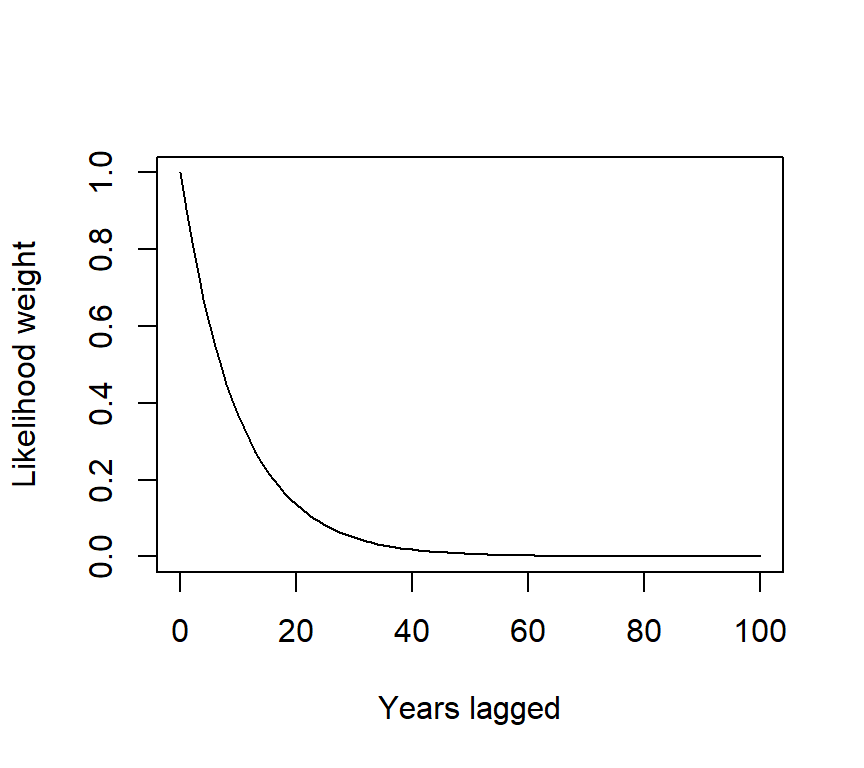

Likelihood weighting for samples collected over time from current year of sampling.

This forward-weighting approach increased the sensitivity of the monitoring sub-model to detect demographic changes in the post-disturbance recovery regime. Data-weighting is increasingly being used in resource monitoring, although how weights are developed and applied to data is a case-by-case basis.

Furthermore, we used penalized normal likelihoods on both $\hat{\alpha_t}$ and $\hat{\beta_t}$ such that:

```r
SRfn <- function(theta, data, lastYr) {
    a.hat <- theta[1]
    b.hat <- exp(theta[2])
    sd.hat <- exp(theta[3])
    rec.mean <- (a.hat * data$spawners)/(1 + ((a.hat - 1)/b.hat) * data$spawners)
    # negative log likelihood on recruitment parameters
    nll <- -1 * sum(dlnorm(data$recruits, meanlog = log(rec.mean), sdlog = sd.hat,
        log = TRUE) * data$weights, na.rm = TRUE)
    # penalized likelihood on estimated alpha
    penalty1 <- -dnorm(a.hat, lastYr$alphaLstYr, 4 * lastYr$alphaLstYr, log = TRUE)
    # penalized likelihood on estimated carrying capacity
    penalty2 <- -dnorm(b.hat, lastYr$metaKLstYr, 4 * lastYr$metaKLstYr, log = TRUE)
    jnll <- sum(c(nll, penalty1, penalty2), na.rm = TRUE)
    return(jnll)
}
```

This above function allows us to assess the bias in $\hat{\alpha_t}$, $\hat{\beta_t}$, and $\hat{MR_t}$ compared to true $\bar{\alpha}$, $\bar{\beta}$, and ${MR}_t$ across the metapopulation. This then allows us to see how much information management & monitoring programs are missing when they assess metapopulations at the aggregate (rather than local) scales.

### Finding maximum sustainable yield

Resource managers measure productivity with a variety of performance reference points (Forrest et al. 2010). One of the most widely used metrics, commonly called *Maximum Sustainable Yield* in fisheries and other harvest literature ($MSY$), relates to the largest loss the population can sustain over an indefinite period of time that maximizes its ability to replenish itself. Under density-dependent growth, individuals’ growth, survival, and reproduction at low population densities are not constrained by limited resources, but overall production is low because there are few individuals. At high densities, limited resources increasingly constrain individual’s reproductive success until the population reaches carrying capacity, and overall production drops to zero because per-capita success is low. However, at some intermediate densities, both per-capita and overall production is high, and population growth is at its maximum point due to the large number of reproducing individuals. At this point, there is the maximum surplus of individuals produced above replacement that can help to withstand disturbance or harvest regimes and contribute to future recovery, either through increasing local patch densities or by emigrating neighboring patches providing “rescue effects.”

Under Beverton-Holt or Ricker density-dependent recuitment, however, there exists no analytical solution for calculating $MSY$. Therefore, we used numerical methods and a one dimensional root finder to iteratively search for the population mortality that maximized surplus production in the metapopulation. We term this mortality $F_{MSY}$ and can use this mortality value to calculate maximum surplus production $MSY$, the adult densities that produce $MSY$ (termed $N_{MSY}$), and the recruits that result from this (termed $R_{MSY}$).

```r
# uniroot numerical search
yieldRoot <- function(alpha, beta, Fcur, model) {
    Ucur <- 1 - exp(-Fcur)
    if (model == "Beverton-Holt") {
        # population model is R ~ (CR * S)/(1+(CR-1)/K * S): reparameterized
        # Beverton-Holt
        adults <- beta * exp(-Fcur)
        recruits <- (alpha * adults)/(1 + ((alpha - 1)/beta) * adults)
        yield <- recruits - adults
    }
    if (model == "Ricker") {
        # population model is R ~ CR * S * e(-log(CR)/K * S): reparameterized Ricker
        adults <- beta * exp(-Fcur)
        recruits <- alpha * adults * exp((-log(alpha)/beta) * adults)
        yield <- recruits - adults
    }
    return(list(recruits = recruits, adults = adults, yield = yield))
}

# Return approximate gradient for integral
fun_yield <- function(Fcur, alpha, beta, delta, model) {
    y1 <- yieldRoot(alpha = alpha, beta = beta, Fcur = Fcur - delta/2, model = model)$yield
    y2 <- yieldRoot(alpha = alpha, beta = beta, Fcur = Fcur + delta/2, model = model)$yield
    approx.gradient <- (y2 - y1)/delta
    return(approx.gradient)
}

# uniroot search for optimal yield and Fmsy
findMSY <- function(alpha, beta, Npatches, model) {
    F_msy <- NULL
    for (i in 1:Npatches) {
        a_p <- alpha[i]
        b_p <- beta[i]
        F_msy[i] <- uniroot(fun_yield, interval = c(0, 1), extendInt = "yes", alpha = a_p,
            beta = b_p, delta = 1e-04, model = model)$root
    }
    MSY <- sapply(1:Npatches, function(x) {
        yieldRoot(alpha = alpha[x], beta = beta[x], Fcur = F_msy[[x]][1], model = model)
    })
    return(list(F_msy = F_msy, MSY = MSY))
}
```

## Scenarios

### Example results

We demonstrate our metapopulation model with an example outcome for a linear network composed of `16` patches, a dispersal rate of `0.01` and a high enough dispersal cost such that individuals are only willing to move to their closest neighboring patches. This limits the strength of potential rescue effects. For this example, patches varied in their productivity and carrying capacity but will have deterministic population dynamics.

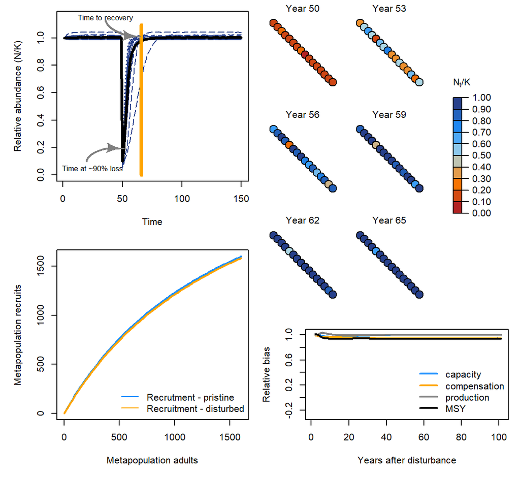

Example iteration of spatial recovery regime of metapopulation with linear topology through time (top left) and space (top right). Recruitment dynamics before and 10 years after disturbance (bottom left). Relative bias in aggregate-scale estimates of carrying capacity, compensation ratio, and recruitment production in recovery phase (bottom right).

We can then contrast this with a different network shape, like a dendritic network.

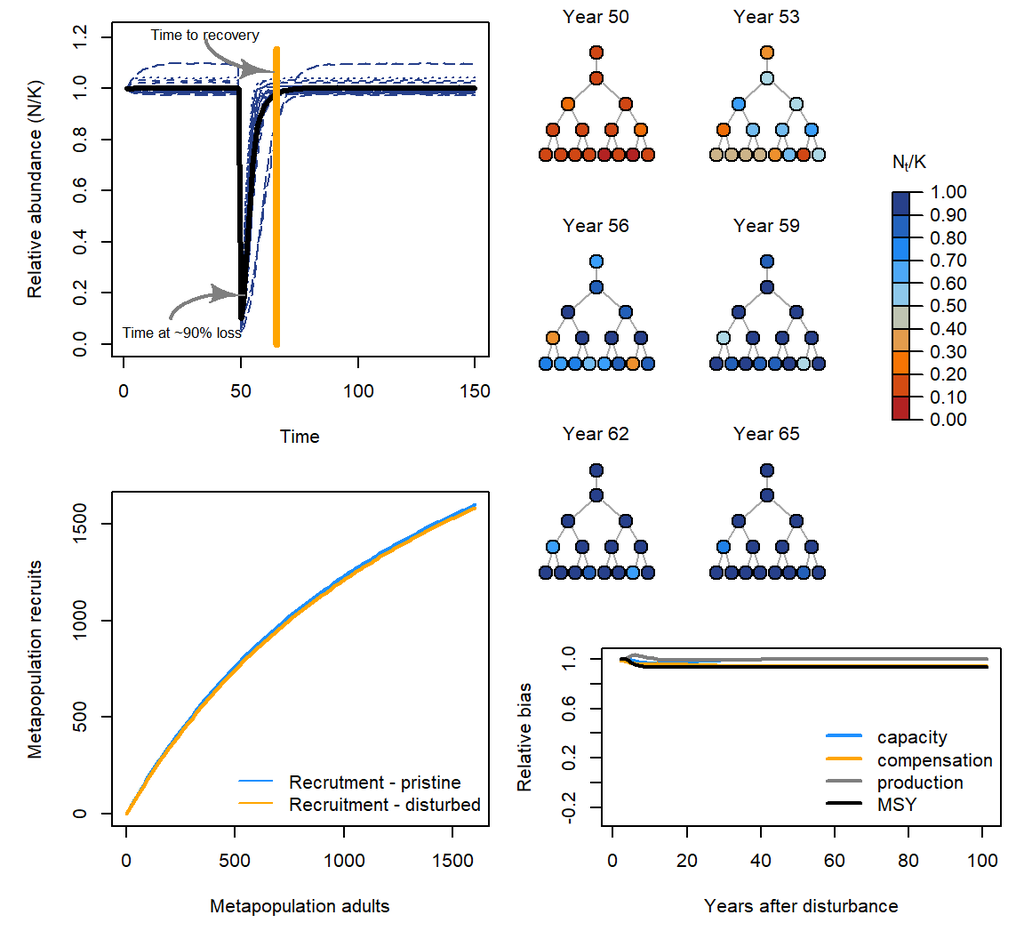

Example iteration of spatial recovery regime of metapopulation with dendritic topology.

Now, let’s add some stochasticity to recruitment and see how this affects the recovery regime.

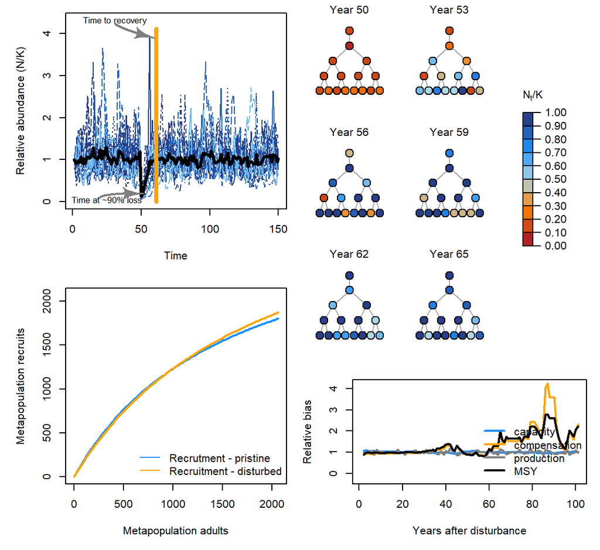

Example iteration of spatial recovery regime of stochastic metapopulation.

Next, we can contrast with a disturbance regime where the disturbance is concentrated on local patches that can be completely extirpated (rather than the disturbance being applied proportionally across all patches e.g., a mixed-stock fishery).

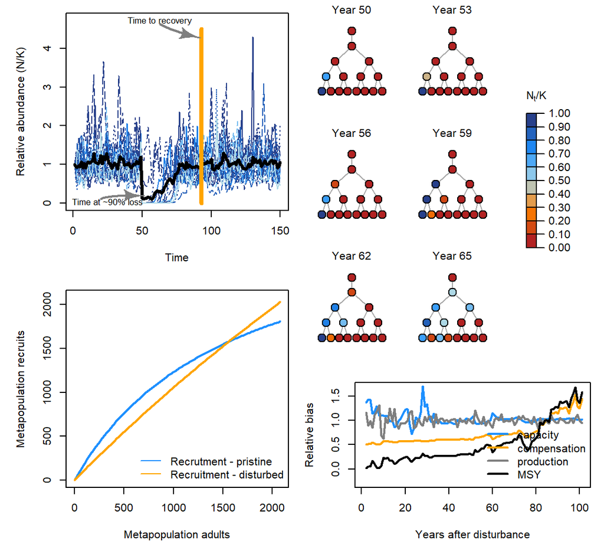

Example iteration of spatial recovery regime of stochastic metapopulation.

## General patterns

### Effects of disturbance regime

The strongest lever influencing recovery in our simulated metapopulations was, by far, the characteristics of the disturbance regime. Specifically, the degree to how locally concentrated the disturbance was on the set of patches was more influential than variable density dependence, dispersal rates, or network topology. This was surprising and not expected in our initial hypotheses. Localized disturbances increased the risk of spatial contraction, reduced recovery rates and aggregate compensation, and increased the risk of a long-term state shift. By altering aggregate compensation, localized disturbance reduced the surplus production of the metapopulation. In other words, through changes in source-sink dynamics, metapopulations under localized disturbance acted less than the sum of their parts – the more localized the impacts, the worse these effects. Uniform disturbances generally left the metapopulation dynamics unaffected with few ecological surprises. These above spatial and temporal recovery processes also appeared tied to one another such that changes to any of them had feedbacks with other recovery metrics.

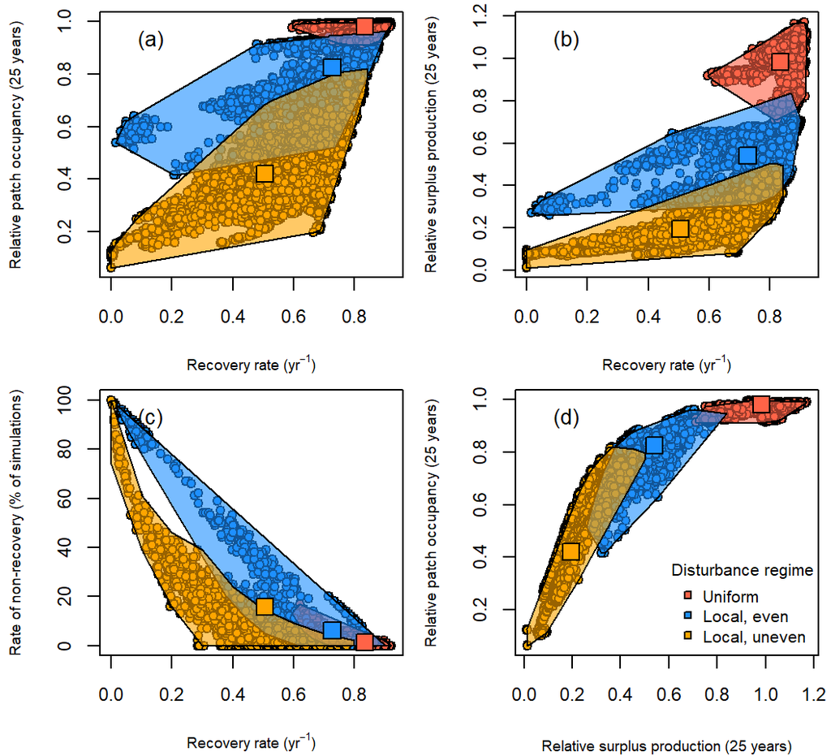

Spatial and temporal recovery patterns along disturbance regimes across all scenarios.

### Role of network structure & dispersal

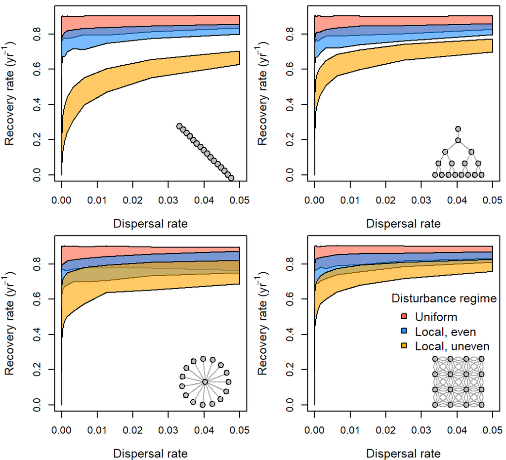

Metapopulation recovery rates along gradients of network configuration, dispersal rates, and spatial distribution of disturbance. The shaded region describes the interquartile range across all scenarios.

Dispersal, landscape structure, and local density-dependence also affected metapopulation recovery patterns in three key ways, though to a lesser extent. First, recovery rates increased with increased dispersal. However, this effect was nonlinear with diminishing benefits of dispersal occurring at ~1-3%, depending on spatial structure and disturbance. Second, more linearized networks had slower recovery times than more connected networks suggesting that rescue effects take some time to cascade through the entire network of patches; but this interacted with the disturbance regime as only local, extirpation exhibited this change in any substantial manner. Last, diversity in local patch compensation and carrying capacities tended to slow metapopulation recoveries - this effect interacted with other factors like stochasticity.

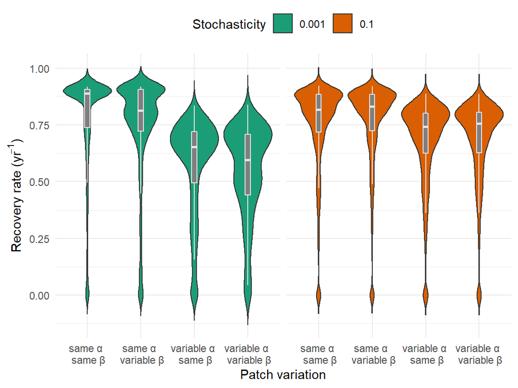

Effects of variable local patch productivities on metapopulation recovery across all scenarios.

### Surprising ecological outcomes

Metapopulation recovery regimes emerged from a complex interplay of density-dependent productivity (shown in Figure 6 of the main text), network structure (shown here), dispersal, and disturbance regimes. Overall, clustering analyses of our model results found evidence for six common outcomes: (1) resilient recovery – metapopulation recovery <10 years, (2) slow recovery – metapopulation recovery >10 years and no other surprise, (3) lost capacity – long-term maximum surplus production <50% before disturbance, (4) hidden collapses – metapopulation recovered (or was recovering) but 50% of patches remain unoccupied, (5) spatial contraction – >25% of patches remain unoccupied and (6) critical risk – metapopulation abundance remains <10% of pre-disturbance. Resilient recovery regimes were most common when disturbance was evenly applied across the network and local patches were identical. Any localized disturbances could create ecological surprises, and the frequency of these surprises were often exacerbated when patches were diverse. Localized, even disturbances tended to reduce recovery by 50% compared to even disturbances (from 16 years to 24 years on average). The riskiest recovery outcomes emerged when disturbance was localized and allowed for extirpation. In these scenarios, recovery was slowed by >100% (from 16 years to >32 years on average), surplus production was often reduced by >50%, long-term patch occupancy was reduced by >35%. Last, note that linear networks tended to have higher risks for long-term spatial contractions.

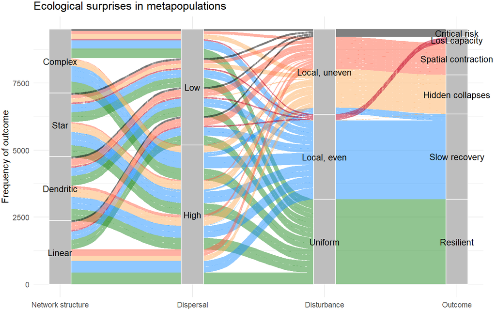

Interplay between network structure, disturbance, and dispersal can lead to suprising recovery outcomes.

### Patterns in recovery rates

Below, we can see three main effects on recovery rates (number of generations to reach recovery). First, recovery gets faster with increased dispersal. Most of the action here takes place at low rates of dispersal indicating most spatial topologies don’t need much dispersal to quicken their recovery. In preliminary runs, dispersal rates of `0.05-0.2` provided similar recovery patterns. Second, more localized disturbances regimes led to slower recovery. Third, linear networks have slower recovery times than interconnected, complex networks suggesting that rescue effects take some time to cascade through the entire network of patches.

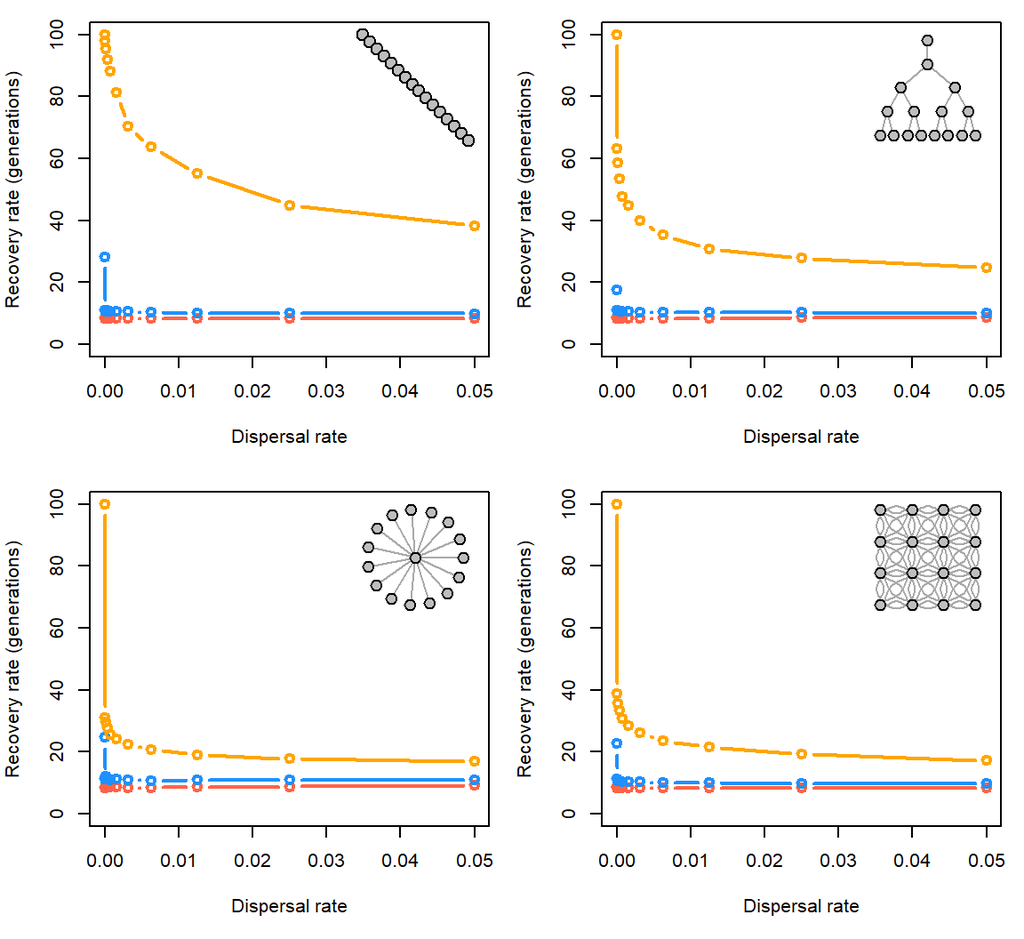

Recovery rates along dispersal, disturbance (red - uniform; blue - localized, even; orange - localized, uneven), and network gradients without stochasticity.

Now, lets show recovery rates for the same scenario with deterministic recruitment but allowing for patches to vary in productivity and carrying capacity. In addition to the same three main effects of dispersal, network, and disturbance noted above, we also see variable patch productivities slows recovery across all scenarios.

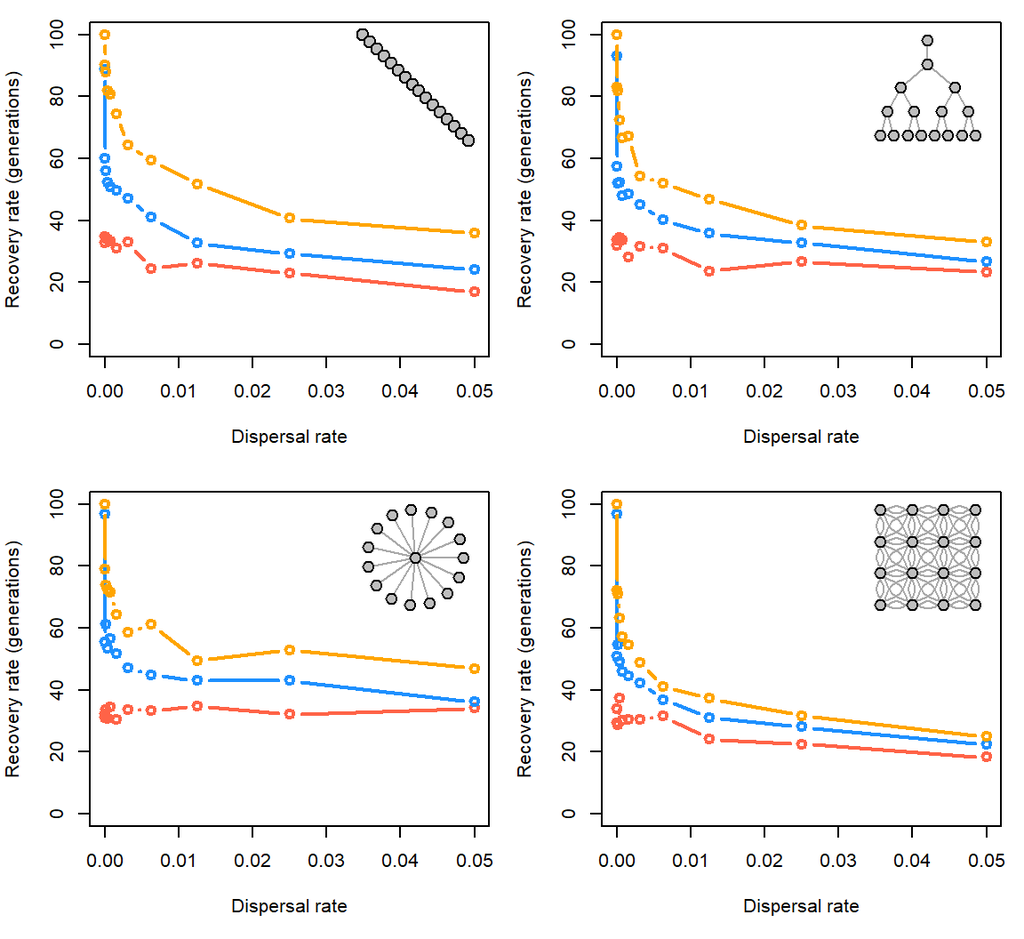

Recovery rates along dispersal, disturbance (red - uniform; blue - localized, even; orange - localized, uneven), and network gradients with variable local productivity and carrying capacities.

Now, lets show recovery rates for the same scenario but allowing for recruitment to be stochastic (but patches are identical in demographic traits). We see the same three main effects of dispersal, network, and disturbance noted above. We also see a few subtle changes: (1) stochasticity slows recovery for even and local disturbance, but (2) quickens recovery for extreme local disturbance.

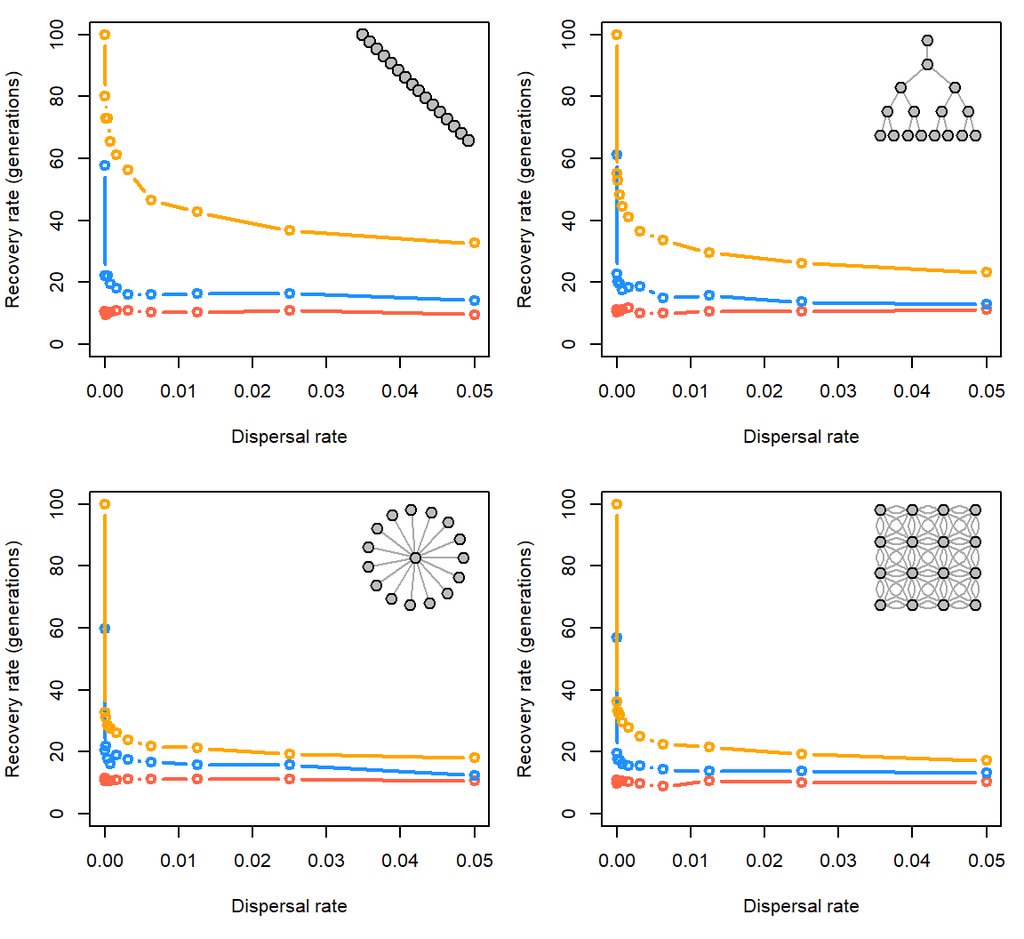

Recovery rates along dispersal, disturbance (red - uniform; blue - localized, even; orange - localized, uneven), and network gradients with stochasticity.

Now, lets show recovery rates for the same scenarios but with spatial and temporal correlations in recruitment stochasticity. In addition to the same effects of stochasticity, we also generally see a small effect of slower recovery times for even and local disturbance, but faster recovery times for extreme localized disturbance.

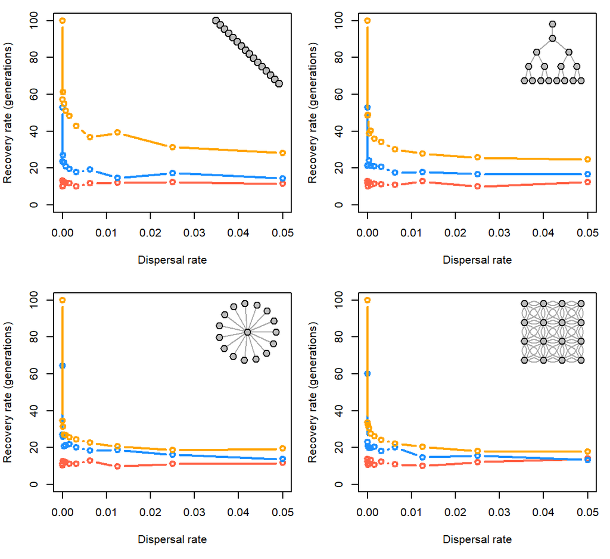

Recovery rates along dispersal, disturbance (red - uniform; blue - localized, even; orange - localized, uneven), and network gradients with high spatial-temporal correlation in recruitment variation.

### Patterns in MSY

#### MSY with deterministic recruitment where patches are the same

We now show similar patterns in how the maximum surplus production of the whole metapopulation (i.e., MSY) shifts in the first 25 years post-disturbance compared to the sum of MSY for each patch. A value of 1.0 would indicate that the disturbed metapopulation can sustain itself against the same disturbance regime as the sum of each patch independently. In other words, is the metapopulation more, less, or equal to the sum of its parts.

Below, we can see two main effects on surplus production. First, spatial disturbance is a strong driver of surplus production with more localized disturbance reducing the surplus. Second, dispersal rates are only limiting in scenarios with localized disturbance. This suggests that (1) evenly disturbed metapopulations operate as the “sum of their parts” but (2) localized disturbances affect metapopulation surplus production leading to slower internal recovery and/or reduced rescue effects from neighboring patches.

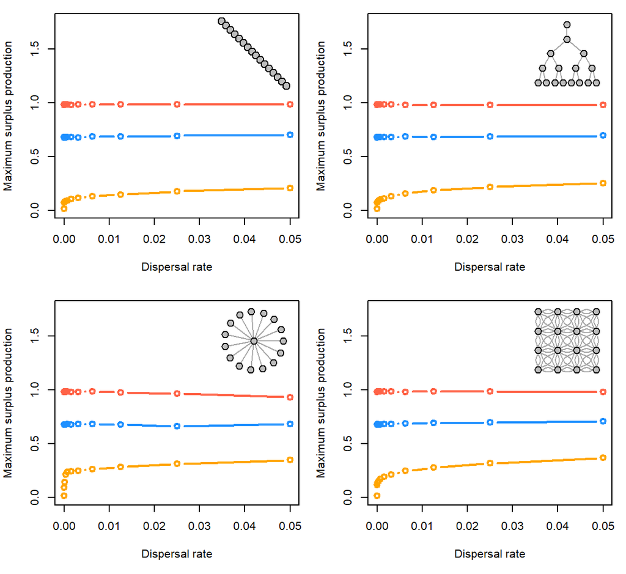

Maximum surplus production along dispersal, disturbance (red - uniform; blue - localized, even; orange - localized, uneven), and network gradients with deterministic recruitment and homogenous patches.

#### MSY with variable patches

Now, we illustrate how variable patch demography affects the 25-year average MSY.

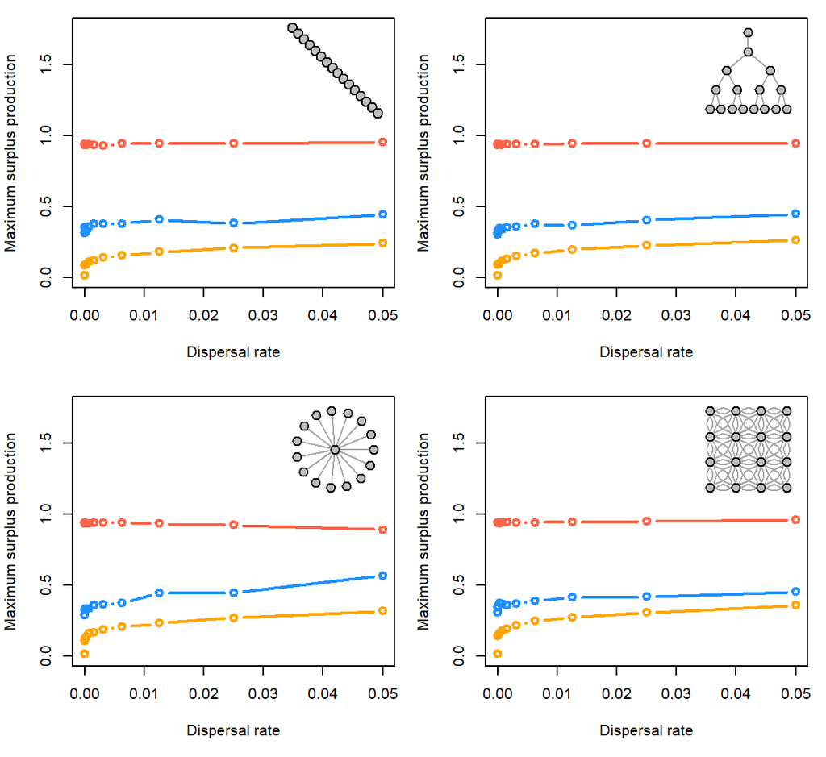

Maximum surplus production along dispersal, disturbance (red - uniform; blue - localized, even; orange - localized, uneven), and network gradients with variable patches.

#### MSY with variable patches and stochasticity

Now, we illustrate how variable patch demography affects the 25-year average MSY.

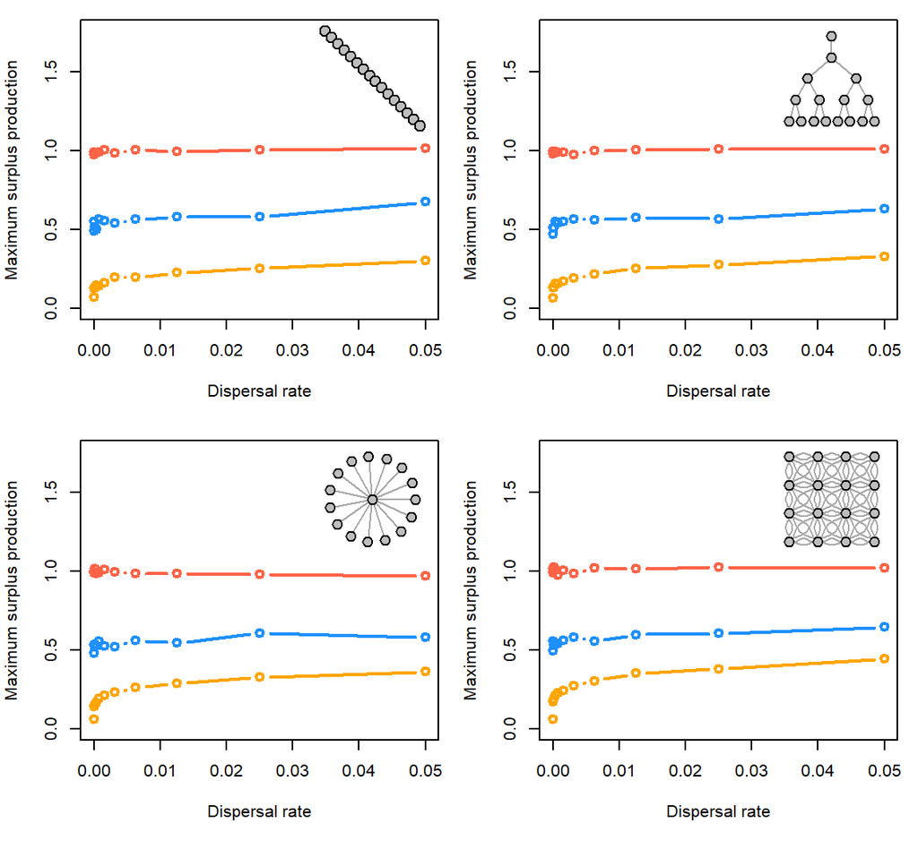

Maximum surplus production along dispersal, disturbance (red - uniform; blue - localized, even; orange - localized, uneven), and network gradients with variable patches and stochasticity.

#### MSY with variable patches, and spatio-temporally correlated stochasticity

Now, we illustrate how variable patch demography and high spatial-temporal correlations in stochastic recruitment affects the 25-year average MSY.

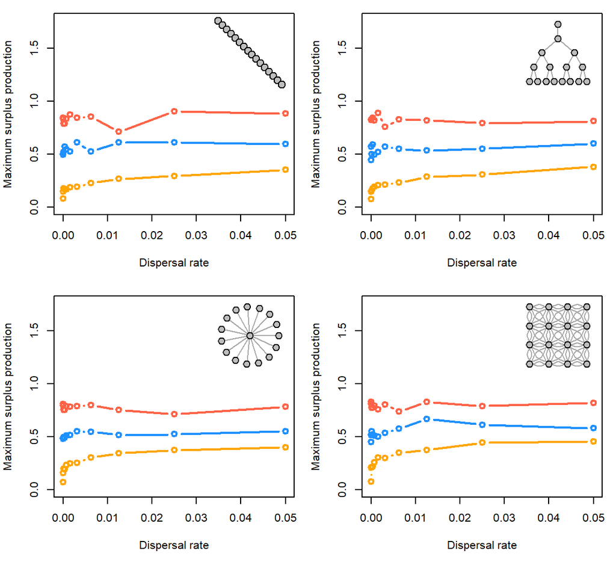

Maximum surplus production along dispersal, disturbance (red - uniform; blue - localized, even; orange - localized, uneven), and network gradients with high spatial-temporal correlation in recruitment stochasticity and variable patches.

### Patterns in long-term collapse (i.e., state shift)

We now show similar patterns in the rate of long-term collapse across the metapopulation after $100$ generations post-disturbance. Collapse rate % was defined as the percent of simulations where metapopulation abundance failed to reach at least `1.0` of the average pre-disturbance abundance for `5` consecutive years after disturbance. This “collapse rate” may reflect the risk of a long-term state shift in metapopulation dynamics after disturbance in the face of stochasticity. We start with a scenario with deterministic recruitment where patches are the same.

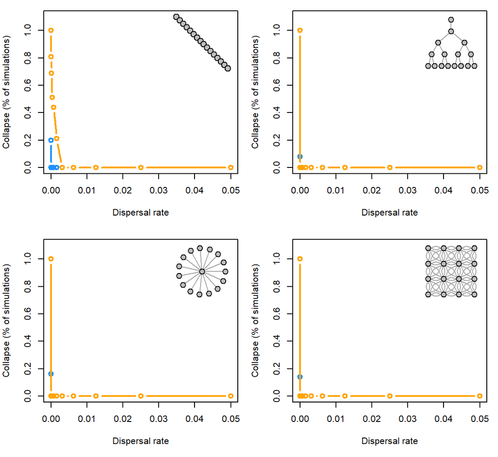

#### State shifts with variable patches

Now, we illustrate how variable patch demography affects the risk of a state shift.

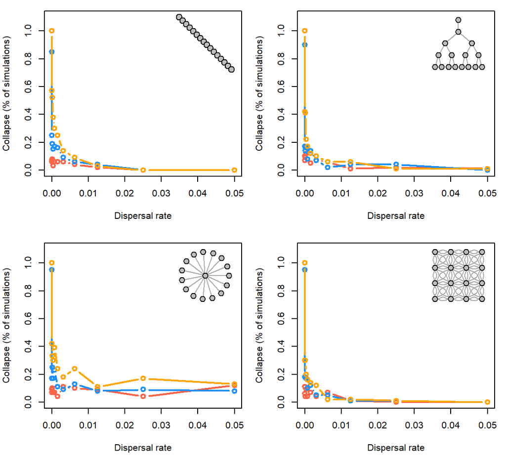

Risk of state shift after 100 generations along dispersal, disturbance (red - uniform; blue - localized, even; orange - localized, uneven), and network gradients with variable patches.

#### State shifts with variable patches and stochasticity

Now, we illustrate how variable patch demography and stochastic recruitment affects the risk of state shift.

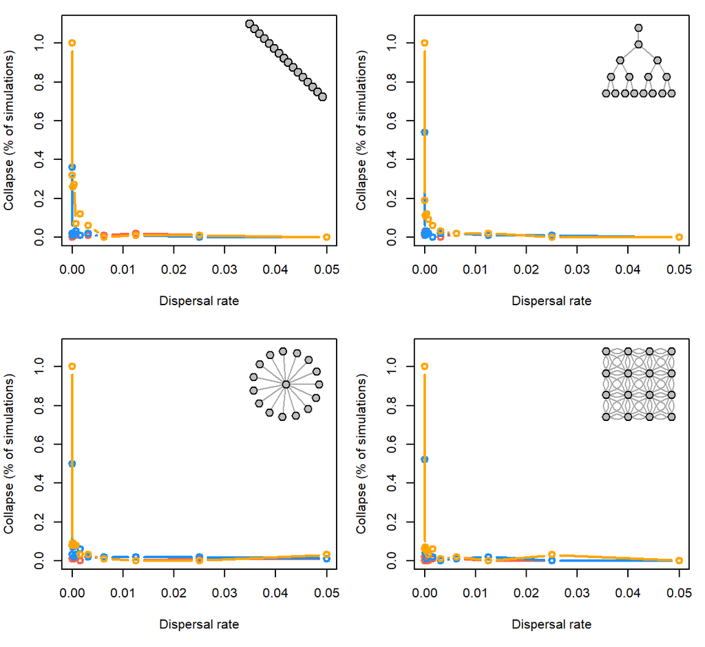

Risk of state shift after 100 generations along dispersal, disturbance (red - uniform; blue - localized, even; orange - localized, uneven), and network gradients with variable patches and stochastic recruitment.

#### State shifts with variable patches, and spatio-temporally correlated stochasticity

Now, we illustrate how variable patch demography and high spatial-temporal correlations in stochastic recruitment affects the risk of a state shift.

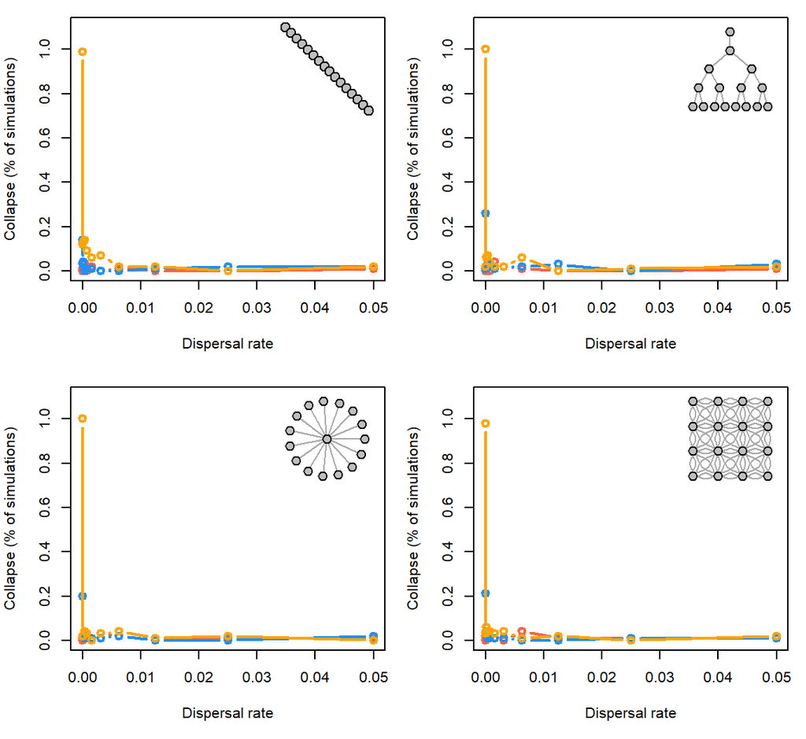

Risk of state shift (lack of recovery or spatial contraction) after 100 generations along dispersal, disturbance (red - uniform; blue - localized, even; orange - localized, uneven), and network gradients with variable patches, and spatial-temporal correlations in stochastic recruitment.

### Patterns in the risk of spatial contraction

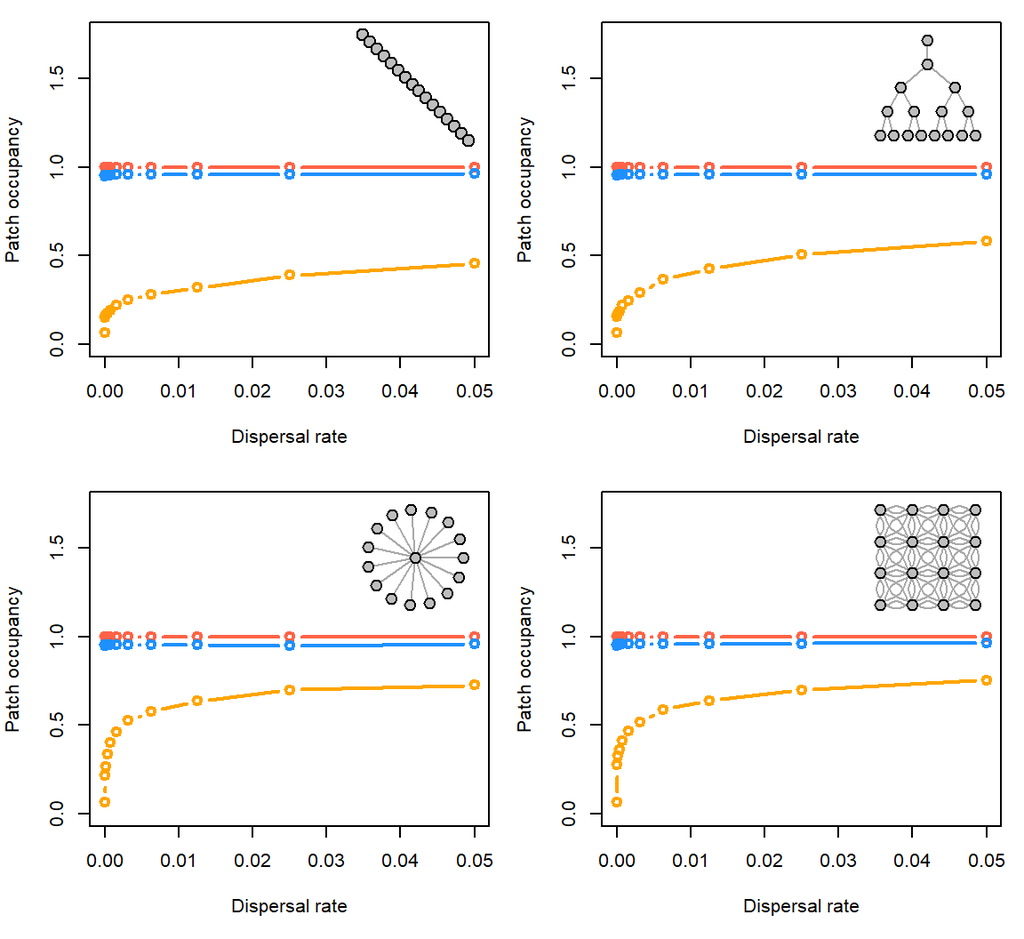

Patch occupancy after 25 years along dispersal, disturbance (red - uniform; blue - localized, even; orange - localized, uneven), and network gradients with deterministic recruitment and homogenous patches.

#### Patch occupancy with variable patches

Now, we illustrate how variable patch demography affects patch occupancy.

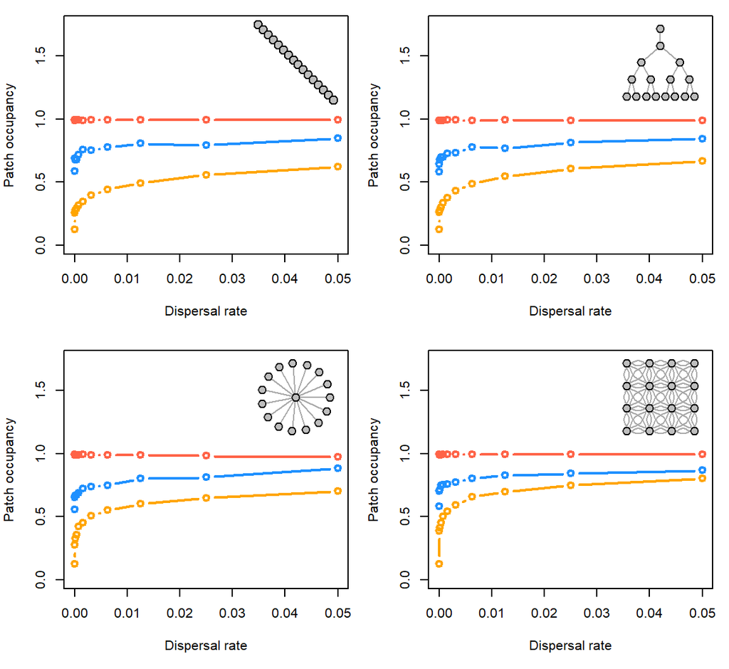

Patch occupancy after 25 years along dispersal, disturbance (red - uniform; blue - localized, even; orange - localized, uneven), and network gradients with variable patches.

#### Patch occupancy with variable patches and stochasticity

Now, we illustrate how variable patch demography and stochastic recruitment affects long-term patch occupancy.

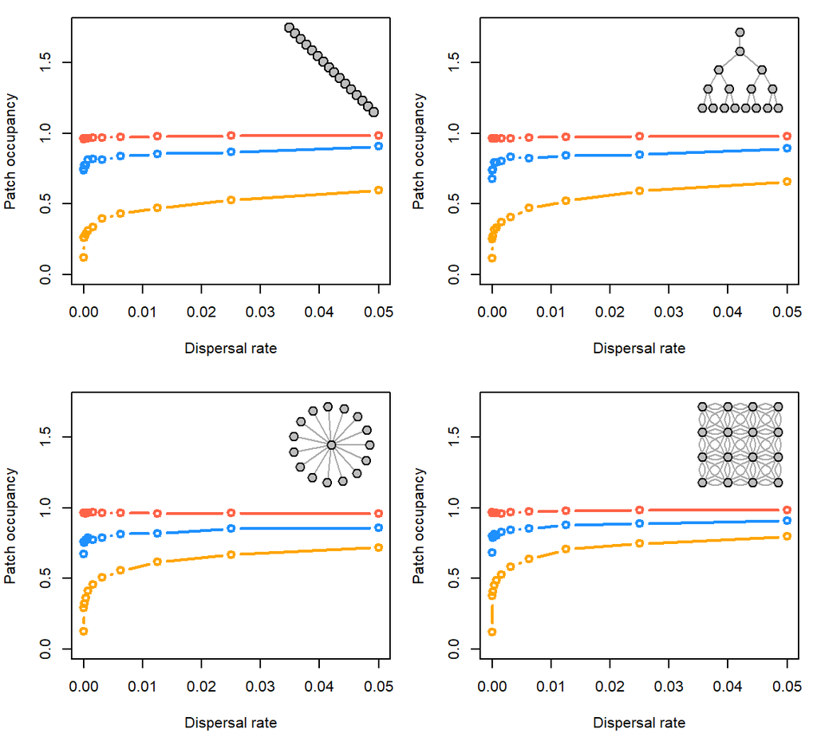

Patch occupancy after 25 years along dispersal, disturbance (red - uniform; blue - localized, even; orange - localized, uneven), and network gradients with variable patches and stochastic recruitment.

#### Patch occupancy with variable patches and spatio-temporally correlated stochasticity in recruitment

Now, we illustrate how variable patch demography and high spatial-temporal correlations in stochastic recruitment affects long-term patch occupancy.

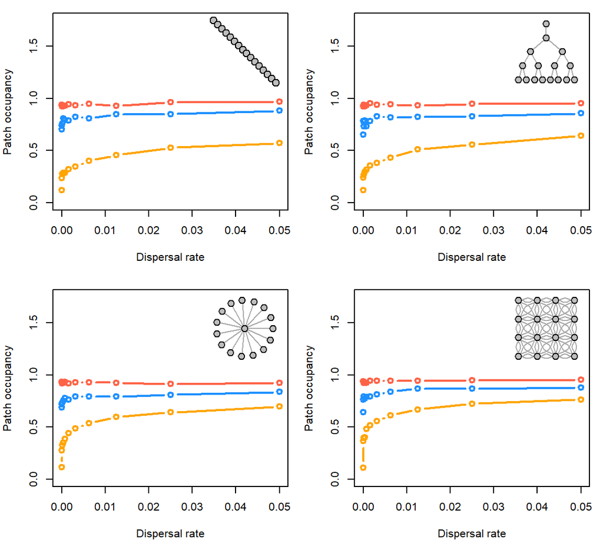

Patch occupancy after 25 years along dispersal, disturbance (red - uniform; blue - localized, even; orange - localized, uneven), and network gradients with variable patches and spatial-temporal correlations in stochastic recruitment.

## References

Anderson, S.C., Moore, J.W., McClure, M.M., Dulvy, N.K. & Cooper, A.B. (2015). Portfolio conservation of metapopulations under climate change. Ecological Applications 25 (2), 559-572. *Ecological Applications*, 25, 559–572.

Csardi, G. & Nepusz, T. (2006). The igraph software package for complex network research. *InterJournal*, Complex Systems, 1695.

Forrest, R.E., McAllister, M.K., Dorn, M.W., Martell, S.J.D. & Stanley, R.D. (2010). Hierarchical Bayesian estimation of recruitment parameters and reference points for Pacific rockfishes (Sebastes spp.) under alternative assumptions about the stock–recruit function. *Canadian Journal of Fisheries and Aquatic Sciences*, 67, 1611–1634.

Hanski, I. (1998). Metapopulation dynamics. *Nature*, 396, 41–49.

Yeakel, J.D., Moore, J.W., Guimarães, P.R. & Aguiar, M.A.M. de. (2014). Synchronisation and stability in river metapopulation networks. *Ecology Letters*, 17, 273–283.

[^1]: Corresponding author - email: kl_wilson@sfu.ca